# ELASTICNET

Carlos Rodríguez-Viña Martínez

9/11/2020

Procedemos a cargar todas las librerías que vamos a utilizar dentro de nuestro trabajo

Procedemos a cargar nuestro Dataframe

Procedemos a estudiar y revisar el dataframe, para tener un mejor entendimiento de los datos que he extraido

- Observamos los valores únicos de cada uno de las filas dentro del datafram

```
## # A tibble: 485 x 28
##    Player Salary NBA_Country NBA_DraftNumber   Age Tm        G    MP   PER `TS%`
##    <chr>   <dbl> <chr>                 <dbl> <dbl> <chr> <dbl> <dbl> <dbl> <dbl>
##  1 Zhou ~ 8.16e5 China                    43    22 HOU      16    87   0.6 0.303
##  2 Zaza ~ 3.48e6 Georgia                  42    33 GSW      66   937  16.8 0.608
##  3 Zach ~ 1.23e7 USA                      19    36 SAC      59  1508  17.3 0.529
##  4 Zach ~ 3.20e6 USA                      13    22 CHI      24   656  14.6 0.499
##  5 Zach ~ 3.06e6 USA                      10    20 POR      62   979   8.2 0.487
##  6 Yogi ~ 1.31e6 USA                      62    24 DAL      79  2238  11.5 0.543
##  7 Xavie~ 7.42e4 USA                      62    30 BOS       2     7  -4.9 0
##  8 Xavie~ 4.61e4 Canada                   62    23 MEM       5   118   0.9 0.315
##  9 Wilso~ 1.20e7 USA                      23    30 DEN      70  2200  11.1 0.543
## 10 Willy~ 1.44e6 Spain                    35    23 TOT      45   430  20.6 0.592
## # ... with 475 more rows, and 18 more variables: `3PAr` <dbl>, FTr <dbl>,
## #   `ORB%` <dbl>, `DRB%` <dbl>, `TRB%` <dbl>, `AST%` <dbl>, `STL%` <dbl>,
## #   `BLK%` <dbl>, `TOV%` <dbl>, `USG%` <dbl>, OWS <dbl>, DWS <dbl>, WS <dbl>,
## #   `WS/48` <dbl>, OBPM <dbl>, DBPM <dbl>, BPM <dbl>, VORP <dbl>
```

- Procedemos a estudiar los duplicados dentro de la columna “Player”, puesto que consideramos razonable que dentro de las otras columnas existan valores iguales.

```
## # A tibble: 483 x 1
##    `NBA$Player`
##    <chr>
##  1 Zhou Qi
##  2 Zaza Pachulia
##  3 Zach Randolph
##  4 Zach LaVine
##  5 Zach Collins
##  6 Yogi Ferrell
##  7 Xavier Silas
##  8 Xavier Rathan-Mayes
##  9 Wilson Chandler
## 10 Willy Hernangomez
## # ... with 473 more rows
```

- Procedemos a calcular cuál es el número de jugadores duplicados dentro del dataframe “NBA”

[output not shown]

[output cut: 26 more lines]

```
## [1] 2
```

- Obtenemos que existen dos valores duplicados y procedemos a eliminarlos de nuestro dataframe.

```
## # A tibble: 483 x 28
##    Player Salary NBA_Country NBA_DraftNumber   Age Tm        G    MP   PER `TS%`
##    <chr>   <dbl> <chr>                 <dbl> <dbl> <chr> <dbl> <dbl> <dbl> <dbl>
##  1 Zhou ~ 8.16e5 China                    43    22 HOU      16    87   0.6 0.303
##  2 Zaza ~ 3.48e6 Georgia                  42    33 GSW      66   937  16.8 0.608
##  3 Zach ~ 1.23e7 USA                      19    36 SAC      59  1508  17.3 0.529
##  4 Zach ~ 3.20e6 USA                      13    22 CHI      24   656  14.6 0.499
##  5 Zach ~ 3.06e6 USA                      10    20 POR      62   979   8.2 0.487
##  6 Yogi ~ 1.31e6 USA                      62    24 DAL      79  2238  11.5 0.543
##  7 Xavie~ 7.42e4 USA                      62    30 BOS       2     7  -4.9 0
##  8 Xavie~ 4.61e4 Canada                   62    23 MEM       5   118   0.9 0.315
##  9 Wilso~ 1.20e7 USA                      23    30 DEN      70  2200  11.1 0.543
## 10 Willy~ 1.44e6 Spain                    35    23 TOT      45   430  20.6 0.592
## # ... with 473 more rows, and 18 more variables: `3PAr` <dbl>, FTr <dbl>,
## #   `ORB%` <dbl>, `DRB%` <dbl>, `TRB%` <dbl>, `AST%` <dbl>, `STL%` <dbl>,
## #   `BLK%` <dbl>, `TOV%` <dbl>, `USG%` <dbl>, OWS <dbl>, DWS <dbl>, WS <dbl>,
## #   `WS/48` <dbl>, OBPM <dbl>, DBPM <dbl>, BPM <dbl>, VORP <dbl>
```

```
## [1] 0
```

Una vez que hemos eliminado, vamos a proceder a crear el modelo de regresión lineal, pero primero tenemos que realizar un pequeño ajsute al nombre de nuestras columnas, porque aparecen con números y simbolos, los cuales la función lm() no va a ser capaza de leer. Es por ello que vamos a susitutir dichos simbolos por caracteres que si que pueda leer.

```
##  [1] "Player"          "Salary"          "NBA_Country"     "NBA_DraftNumber"
##  [5] "Age"             "Tm"              "G"               "MP"
##  [9] "PER"             "TS."             "threePAr"        "FTr"
## [13] "ORB."            "DRB."            "TRB."            "AST."
## [17] "STL."            "BLK."            "TOV."            "USG."
## [21] "OWS"             "DWS"             "WS"              "WS.48"
## [25] "OBPM"            "DBPM"            "BPM"             "VORP"
```

Procedemos a todos los valores nullos que tenemos en el dataframe los llenamos con 0, podríamos llenarlo con la media de los valors de la columna o con la media de los jugadores igual.

```
##          Player          Salary     NBA_Country NBA_DraftNumber             Age
##               0               0               0               0               0
##              Tm               G              MP             PER             TS.
##               0               0               0               0               2
##        threePAr             FTr            ORB.            DRB.            TRB.
##               2               2               0               0               0
##            AST.            STL.            BLK.            TOV.            USG.
##               0               0               0               2               0
##             OWS             DWS              WS           WS.48            OBPM
##               0               0               0               0               0
##            DBPM             BPM            VORP
##               0               0               0
```

Convertimos la variable salario en logaritmo de salario

```r
logNBA <- NBA %>% mutate(Salary = log(Salary))
```

Creamos el train sample y el test sample

```r
set.seed(123)

NBA_split <- initial_split(logNBA, prop = .7)
NBA_train <- training(NBA_split)
NBA_test <- testing(NBA_split)
```

Creamos el modelo para la muestra de train y de test

```r
NBA_train_x <- model.matrix(Salary~., NBA_train)
NBA_train_y <- log(NBA_train$Salary)

NBA_test_x <- model.matrix(Salary~., NBA_test)
NBA_test_y <- log(NBA_test$Salary)
```

Aplicamos la función gmlet para ver los valores de alpha que posteriormente vamos a utilizar para dibujar la gráfica.

```r
lasso_nba <- glmnet(NBA_train_x,NBA_train_y, alpha = 1.0)
elastic1 <- glmnet(NBA_train_x,NBA_train_y, alpha = 0.25)
elastic2 <- glmnet(NBA_train_x,NBA_train_y, alpha = 0.75)
ridge_nba <- glmnet(NBA_train_x,NBA_train_y, alpha = 0.0)
```

Dibujo las gráficas

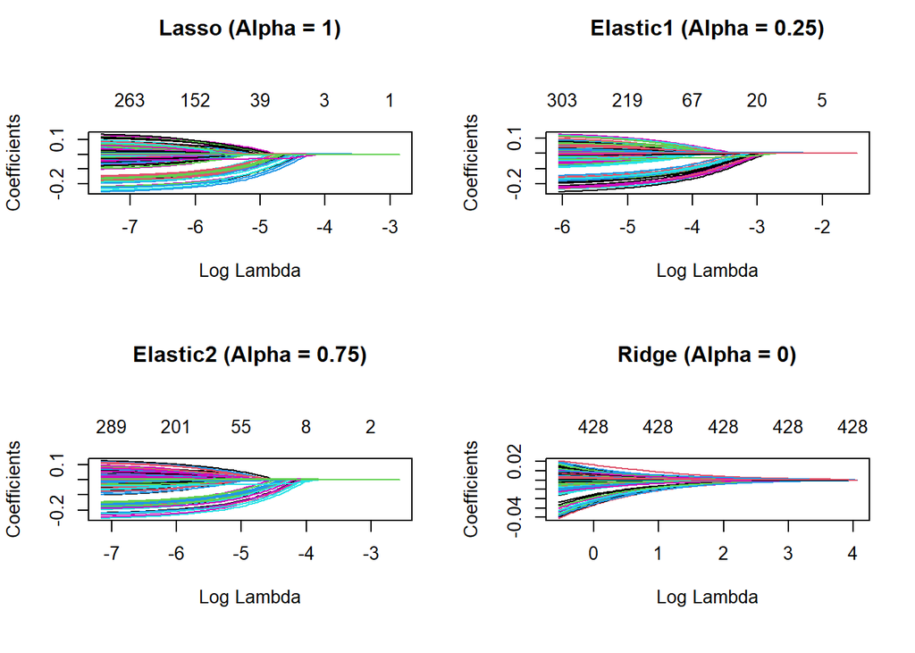

```r
par(mfrow = c(2,2), mar = c(6,4,6,2) + 0.1)
plot(lasso_nba, xvar = "lambda", main = "Lasso (Alpha = 1)\n\n\n")
plot(elastic1, xvar = "lambda", main = "Elastic1 (Alpha = 0.25)\n\n\n")
plot(elastic2, xvar = "lambda", main = "Elastic2 (Alpha = 0.75)\n\n\n")
plot(ridge_nba, xvar = "lambda", main = "Ridge (Alpha = 0)\n\n\n")
```

Mantenemos la muestra constante para todos los modelos

```r
fold_idnba <- sample(1:20, size = length(NBA_train_y), replace = TRUE)
```

Buscamos por todos los valores de alpha

```r
tuning_grid <- tibble::tibble(
  alpha       = seq(0,1, by= .1), #Creo una tabla con todos los valores de alpha
  mse_min     = NA, # y para el resto de variables le indico que es 0.
  mse_1se     = NA,
  lambda_min  = NA,
  lambda_1se  = NA
)
tuning_grid
```

```
## # A tibble: 11 x 5
##    alpha mse_min mse_1se lambda_min lambda_1se
##    <dbl> <lgl>   <lgl>   <lgl>      <lgl>
##  1   0   NA      NA      NA         NA
##  2   0.1 NA      NA      NA         NA
##  3   0.2 NA      NA      NA         NA
##  4   0.3 NA      NA      NA         NA
##  5   0.4 NA      NA      NA         NA
##  6   0.5 NA      NA      NA         NA
##  7   0.6 NA      NA      NA         NA
##  8   0.7 NA      NA      NA         NA
##  9   0.8 NA      NA      NA         NA
## 10   0.9 NA      NA      NA         NA
## 11   1   NA      NA      NA         NA
```

Procedemos Aplicar la función cv elastic para todos los valores de alpha entro 0 y 1

```r
for(i in seq_along(tuning_grid$alpha)) { # Indico para todos los valores de alpha de la f.turning grif
                                        # que se aplique la función de abajo
  #Metemos el modelo para cada valor de alpha
  fit <- cv.glmnet(NBA_train_x, NBA_train_y, alpha = tuning_grid$alpha[i], foldid = fold_idnba)
  # alpha = a los valores de alpha indicados en la función de turning grid
  # fol_id =  a la muestra de valores que previamente había creado.

  #Extraemos los valores lambda y MSE
  tuning_grid$mse_min[i] <- fit$cvm[fit$lambda == fit$lambda.min]
  tuning_grid$mse_1se[i] <- fit$cvm[fit$lambda == fit$lambda.1se]
  tuning_grid$lambda_min[i] <- fit$lambda.min
  tuning_grid$lambda_1se[i] <- fit$lambda.1se

}

tuning_grid
```

```
## # A tibble: 11 x 5
##    alpha mse_min mse_1se lambda_min lambda_1se
##    <dbl>   <dbl>   <dbl>      <dbl>      <dbl>
##  1   0   0.00732 0.00785   0.579        1.01
##  2   0.1 0.00572 0.00615   0.00839      0.0783
##  3   0.2 0.00558 0.00601   0.00382      0.0542
##  4   0.3 0.00553 0.00595   0.00222      0.0416
##  5   0.4 0.00551 0.00593   0.00145      0.0342
##  6   0.5 0.00549 0.00591   0.00116      0.0287
##  7   0.6 0.00548 0.00590   0.000964     0.0250
##  8   0.7 0.00547 0.00586   0.000827     0.0214
##  9   0.8 0.00546 0.00588   0.000723     0.0197
## 10   0.9 0.00545 0.00588   0.000643     0.0183
## 11   1   0.00542 0.00584   0.000579     0.0165
```

Una vez realizado el modelo me devuelve que cuando alpha=1,la función me da el valor de lambda optimo que es 0,000579 y este lambda me ofrece el valor del mínimo error de del modelo entre todos los valores de alpha

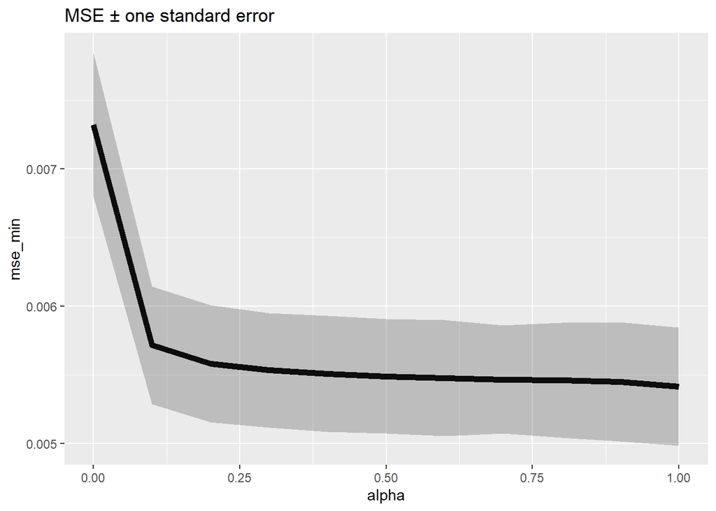

```r
tuning_grid %>%
  mutate(se = mse_1se - mse_min) %>%
  ggplot(aes(alpha, mse_min)) +
  geom_line(size = 2) +
  geom_ribbon(aes(ymax = mse_min + se, ymin = mse_min - se), alpha = .25) +
  ggtitle("MSE ± one standard error")
```